# ID529: Modeling workflows, The RMarkdown Version

Jarvis Chen

2023-01-15

Here, we illustrate how the `gtsummary`, `sjPlot`, `stargazer`, and `ggstatsplot` packages can be used in an RMarkdown document to generate pretty tables and figures. We show a few more options for adjusting things like table captions to make your tables and figures more informative.

This example uses the NHANES dataset and the linear and logistic regression models that we looked at on Day 4.

# Setting up the data and fitting linear and logistic regression models to use as examples

```r
# Set up the analytic dataset
df <- NHANES  %>%
  # Remember that we have to restrict to people 25 and above
  filter(Age>=25)  %>%
  # recoding of the variables we're going to use
  mutate(agecat = case_when(
      Age < 35 ~ "25-34",
      35 <= Age & Age < 45 ~ "35-44",
      Age >= 45 & Age < 55 ~ "45-54",
      Age >= 55 & Age < 65 ~ "55-64",
      Age >= 65 & Age < 75 ~ "65-74",
      Age >= 75 ~ "75+"),
    # We want College Grad to be the reference category for education, so we'll
    # re-order the factor so that it is reversed from the way it came in the NHANES dataset
    Education = factor(Education,
                       levels=rev(levels(NHANES$Education))),
    # Here we collapse Hispanic and Mexican into the Hispanic category
    racecat = factor(case_when(
      Race1 %in% c("Hispanic", "Mexican") ~ "Hispanic",
      Race1 %in% c("Asian", "Other") ~ "Other Non-Hispanic",
      Race1 == "Black" ~ "Black Non-Hispanic",
      Race1 == "White" ~ "White Non-Hispanic"),
      levels = c("White Non-Hispanic", "Black Non-Hispanic", "Hispanic", "Other Non-Hispanic"))
  ) %>%
  # select just variables we are going to use in the analysis
  select(ID, SurveyYr, Gender, Age, agecat, Education, racecat, BPSysAve, SmokeNow)


# Knowing that there are differing amounts of missing data in the different variables,
# it would be better if we defined our analytic dataset based non-missing data on all of
# variables we know we are going to include in our analysis.
# NOTE: There is a substantial amount of missing data, so complete case analysis could
# yield biased results if the data are not Missing Completely At Random!

df_completecase <- df %>%
  filter(!is.na(BPSysAve) & !is.na(agecat) & !is.na(Gender) & !is.na(racecat))
```

```r
# Fit the linear regression models of interest
# relating BPSysAve to Education, and adjusting
# for covariates: age category, gender, race category, and the interaction
# of race and gender

lm_model1 <- lm(BPSysAve ~ factor(Education),
                data=df_completecase)
lm_model2 <- lm(BPSysAve ~ factor(Education) + factor(agecat) + Gender,
                data=df_completecase)
lm_model3 <- lm(BPSysAve ~ factor(Education) + factor(agecat) + Gender + factor(racecat),
                data=df_completecase)

lm_model4 <- lm(BPSysAve ~ factor(Education) + factor(agecat) + interaction(Gender,factor(racecat)),
                 data=df_completecase)

# Fit the logistic regression models of interest
# relating the same covariates to SmokeNow

logistic_model1 <- glm(SmokeNow ~ factor(Education),
              family=binomial(link=logit),
              data=df_completecase)

logistic_model2 <- glm(SmokeNow ~ factor(Education) + factor(agecat) + Gender,
              family=binomial(link=logit),
              data=df_completecase)

logistic_model3 <- glm(SmokeNow ~ factor(Education) + factor(agecat) + Gender + factor(racecat),
              family=binomial(link=logit),
              data=df_completecase)

logistic_model4 <- glm(SmokeNow ~ factor(Education) + factor(agecat) + interaction(Gender,factor(racecat)),
               family=binomial(link=logit),
               data=df_completecase)

summary(logistic_model4)
```

```
##
## Call:
## glm(formula = SmokeNow ~ factor(Education) + factor(agecat) +
##     interaction(Gender, factor(racecat)), family = binomial(link = logit),
##     data = df_completecase)
##
## Coefficients:
##                                                               Estimate
## (Intercept)                                                   -0.38896
## factor(Education)Some College                                  0.85809
## factor(Education)High School                                   1.03404
## factor(Education)9 - 11th Grade                                1.61269
## factor(Education)8th Grade                                     1.33465
## factor(agecat)35-44                                           -0.38197
## factor(agecat)45-54                                           -0.67390
## factor(agecat)55-64                                           -0.88896
## factor(agecat)65-74                                           -1.73475
## factor(agecat)75+                                             -2.86574
## interaction(Gender, factor(racecat))male.White Non-Hispanic   -0.08169
## interaction(Gender, factor(racecat))female.Black Non-Hispanic  0.64043
## interaction(Gender, factor(racecat))male.Black Non-Hispanic    0.44131
## interaction(Gender, factor(racecat))female.Hispanic           -0.38558
## interaction(Gender, factor(racecat))male.Hispanic             -0.30311
## interaction(Gender, factor(racecat))female.Other Non-Hispanic  1.06416
## interaction(Gender, factor(racecat))male.Other Non-Hispanic    0.83307
##                                                               Std. Error
## (Intercept)                                                      0.13482
## factor(Education)Some College                                    0.11812
## factor(Education)High School                                     0.12774
## factor(Education)9 - 11th Grade                                  0.13973
## factor(Education)8th Grade                                       0.19639
## factor(agecat)35-44                                              0.12837
## factor(agecat)45-54                                              0.12395
## factor(agecat)55-64                                              0.13085
## factor(agecat)65-74                                              0.15744
## factor(agecat)75+                                                0.22715
## interaction(Gender, factor(racecat))male.White Non-Hispanic      0.09642
## interaction(Gender, factor(racecat))female.Black Non-Hispanic    0.21721
## interaction(Gender, factor(racecat))male.Black Non-Hispanic      0.18821
## interaction(Gender, factor(racecat))female.Hispanic              0.23786
```

[output cut: 35 more lines]

```
## interaction(Gender, factor(racecat))female.Hispanic
## interaction(Gender, factor(racecat))male.Hispanic             .
## interaction(Gender, factor(racecat))female.Other Non-Hispanic ***
## interaction(Gender, factor(racecat))male.Other Non-Hispanic   ***
## ---
## Signif. codes:  0 '***' 0.001 '**' 0.01 '*' 0.05 '.' 0.1 ' ' 1
##
## (Dispersion parameter for binomial family taken to be 1)
##
##     Null deviance: 3964.3  on 2898  degrees of freedom
## Residual deviance: 3446.2  on 2882  degrees of freedom
##   (3432 observations deleted due to missingness)
## AIC: 3480.2
##
## Number of Fisher Scoring iterations: 4
```

```r
broom::tidy(lm_model4)
```

```
## # A tibble: 17 × 5
##    term                                   estimate std.error statistic   p.value
##    <chr>                                     <dbl>     <dbl>     <dbl>     <dbl>
##  1 (Intercept)                             109.        0.598   183.    0
##  2 factor(Education)Some College             2.89      0.512     5.65  1.69e-  8
##  3 factor(Education)High School              3.41      0.572     5.97  2.46e-  9
##  4 factor(Education)9 - 11th Grade           2.67      0.677     3.94  8.31e-  5
##  5 factor(Education)8th Grade                3.68      0.929     3.96  7.58e-  5
##  6 factor(agecat)35-44                       4.06      0.616     6.59  4.83e- 11
##  7 factor(agecat)45-54                       6.64      0.614    10.8   4.70e- 27
##  8 factor(agecat)55-64                      12.7       0.649    19.6   8.15e- 83
##  9 factor(agecat)65-74                      15.8       0.736    21.5   3.14e- 99
## 10 factor(agecat)75+                        23.8       0.832    28.7   6.50e-170
## 11 interaction(Gender, factor(racecat))m…    3.70      0.477     7.74  1.11e- 14
## 12 interaction(Gender, factor(racecat))f…    4.79      0.903     5.30  1.18e-  7
## 13 interaction(Gender, factor(racecat))m…    7.73      0.952     8.12  5.69e- 16
## 14 interaction(Gender, factor(racecat))f…   -0.716     0.904    -0.792 4.28e-  1
## 15 interaction(Gender, factor(racecat))m…    4.38      0.858     5.11  3.40e-  7
## 16 interaction(Gender, factor(racecat))f…   -3.03      1.08     -2.81  4.95e-  3
## 17 interaction(Gender, factor(racecat))m…    4.30      1.12      3.82  1.33e-  4
```

# Summary tables using `gtsummary`

We can integrate calls to `gtsummary::tbl_regression` into our RMarkdown document and get pretty tables to appear in our knitted document.

```r
# Creating Pretty Tables -----------------------------------------------------------

tbl_lm_model1 <-
  tbl_regression(lm_model1, label = list('factor(Education)' ~ 'Education')) %>%
  bold_labels() %>%
    modify_caption("**Table 1:** Model 1 estimates showing crude associations of educational categories with average systolic blood pressure")

# We can also add some model fit statistics to the output
# by using add_glance_table()
tbl_lm_model1_glance <-
  tbl_regression(lm_model1, label = list('factor(Education)' ~ 'Education')) %>%
  bold_labels() %>%
  add_glance_table() %>%
  modify_caption("**Table 1:** Model 1 estimates showing crude associations of educational categories with average systolic blood pressure")
tbl_lm_model1_glance
```

**Table 1:** Model 1 estimates showing crude associations of educational categories with average systolic blood pressure

| **Characteristic** | **Beta** | **95% CI**<sup>1</sup> | **p-value** |
| --- | --- | --- | --- |
| Education |  |  |  |
| College Grad | — | — |  |
| Some College | 3.8 | 2.7, 4.8 | <0.001 |
| High School | 5.1 | 3.9, 6.4 | <0.001 |
| 9 - 11th Grade | 4.7 | 3.3, 6.1 | <0.001 |
| 8th Grade | 7.9 | 6.1, 9.8 | <0.001 |
| R² | 0.019 |  |  |
| Adjusted R² | 0.018 |  |  |
| Sigma | 17.3 |  |  |
| Statistic | 30.4 |  |  |
| p-value | <0.001 |  |  |
| df | 4 |  |  |
| Log-likelihood | -26,991 |  |  |
| AIC | 53,994 |  |  |
| BIC | 54,035 |  |  |
| Deviance | 1,886,669 |  |  |
| Residual df | 6,319 |  |  |
| No. Obs. | 6,324 |  |  |

<sup>1</sup> CI = Confidence Interval

```r
# What if I want to compare my models

# We can set the gtsummary theme so that the table is formatted
# e.g. here we format to the JAMA journal format
set_gtsummary_theme(theme_gtsummary_journal("jama"))
```

```
## Setting theme `JAMA`
## Setting theme `JAMA`
```

```r
# First we format each of the models using tbl_regression

# Note for this first one that I am showing how to integrate this
# into a workflow where you start with the analytic data frame,
# pipe it into lm() and then pipe the results into
# tbl_regression
tbl_lm_model1 <- df_completecase %>%
  lm(BPSysAve ~ factor(Education),
     data=.) %>%
  tbl_regression(intercept=TRUE,
                 label = list('factor(Education)' ~ 'Education'))

tbl_lm_model2 <- lm_model2 %>%
  tbl_regression(intercept=TRUE,
                 label = list('factor(Education)' ~ 'Education',
                              'factor(agecat)' ~ 'Age category'))

tbl_lm_model3 <- lm_model3 %>%
  tbl_regression(intercept=TRUE,
                 label = list('factor(Education)' ~ 'Education',
                              'factor(agecat)' ~ 'Age category',
                              'factor(racecat)' ~ 'Racialized group'))

tbl_lm_model4 <- lm_model4 %>%
  tbl_regression(intercept=TRUE,
                 label = list('factor(Education)' ~ 'Education',
                              'factor(agecat)' ~ 'Age category',
                              'interaction(Gender, factor(racecat))' ~ 'Gender X Racialized group'),
                 )


# Now that each of the models has been formatted, I can use tbl_merge to
# put the models together to be shown side-by-side
tbl_merge_ex1 <-
  tbl_merge(
    tbls = list(tbl_lm_model1,
                tbl_lm_model2,
                tbl_lm_model3,
                tbl_lm_model4),
    # the tab_spanner argument specifies the headings at the top of the table
    # that span multiple columns
    tab_spanner = c("**Model 1**", "**Model 2**", "**Model 3**", "**Model 4**")
  ) %>%
  modify_caption("Table 2: Comparison of linear model results")

tbl_merge_ex1
```

Table 2: Comparison of linear model results

| **Characteristic** | **Model 1** **Beta** **(95% CI)**<sup>1</sup> | **Model 1** **p-value** | **Model 2** **Beta** **(95% CI)**<sup>1</sup> | **Model 2** **p-value** | **Model 3** **Beta** **(95% CI)**<sup>1</sup> | **Model 3** **p-value** | **Model 4** **Beta** **(95% CI)**<sup>1</sup> | **Model 4** **p-value** |
| --- | --- | --- | --- | --- | --- | --- | --- | --- |
| (Intercept) | 119 (118 to 119) | <0.001 | 109 (108 to 110) | <0.001 | 109 (108 to 110) | <0.001 | 109 (108 to 110) | <0.001 |
| Education |  |  |  |  |  |  |  |  |
| College Grad | — |  | — |  | — |  | — |  |
| Some College | 3.8 (2.7 to 4.8) | <0.001 | 3.2 (2.2 to 4.2) | <0.001 | 2.9 (1.9 to 3.9) | <0.001 | 2.9 (1.9 to 3.9) | <0.001 |
| High School | 5.1 (3.9 to 6.4) | <0.001 | 3.9 (2.7 to 5.0) | <0.001 | 3.4 (2.3 to 4.5) | <0.001 | 3.4 (2.3 to 4.5) | <0.001 |
| 9 - 11th Grade | 4.7 (3.3 to 6.1) | <0.001 | 3.2 (1.9 to 4.5) | <0.001 | 2.7 (1.3 to 4.0) | <0.001 | 2.7 (1.3 to 4.0) | <0.001 |
| 8th Grade | 7.9 (6.1 to 9.8) | <0.001 | 3.7 (1.9 to 5.4) | <0.001 | 3.6 (1.8 to 5.5) | <0.001 | 3.7 (1.9 to 5.5) | <0.001 |
| Age category |  |  |  |  |  |  |  |  |
| 25-34 |  |  | — |  | — |  | — |  |
| 35-44 |  |  | 4.0 (2.8 to 5.2) | <0.001 | 4.1 (2.9 to 5.3) | <0.001 | 4.1 (2.8 to 5.3) | <0.001 |
| 45-54 |  |  | 6.7 (5.5 to 7.9) | <0.001 | 6.7 (5.5 to 7.9) | <0.001 | 6.6 (5.4 to 7.8) | <0.001 |
| 55-64 |  |  | 13 (11 to 14) | <0.001 | 13 (11 to 14) | <0.001 | 13 (11 to 14) | <0.001 |
| 65-74 |  |  | 16 (14 to 17) | <0.001 | 16 (14 to 17) | <0.001 | 16 (14 to 17) | <0.001 |
| 75+ |  |  | 24 (22 to 25) | <0.001 | 24 (22 to 25) | <0.001 | 24 (22 to 25) | <0.001 |
| Gender |  |  |  |  |  |  |  |  |
| female |  |  | — |  | — |  |  |  |
| male |  |  | 4.0 (3.2 to 4.8) | <0.001 | 4.1 (3.3 to 4.8) | <0.001 |  |  |
| Racialized group |  |  |  |  |  |  |  |  |
| White Non-Hispanic |  |  |  |  | — |  |  |  |
| Black Non-Hispanic |  |  |  |  | 4.4 (3.1 to 5.7) | <0.001 |  |  |
| Hispanic |  |  |  |  | 0.03 (-1.2 to 1.3) | 0.96 |  |  |
| Other Non-Hispanic |  |  |  |  | -1.3 (-2.8 to 0.24) | 0.10 |  |  |
| Gender X Racialized group |  |  |  |  |  |  |  |  |
| female.White Non-Hispanic |  |  |  |  |  |  | — |  |
| male.White Non-Hispanic |  |  |  |  |  |  | 3.7 (2.8 to 4.6) | <0.001 |
| female.Black Non-Hispanic |  |  |  |  |  |  | 4.8 (3.0 to 6.6) | <0.001 |
| male.Black Non-Hispanic |  |  |  |  |  |  | 7.7 (5.9 to 9.6) | <0.001 |
| female.Hispanic |  |  |  |  |  |  | -0.72 (-2.5 to 1.1) | 0.43 |
| male.Hispanic |  |  |  |  |  |  | 4.4 (2.7 to 6.1) | <0.001 |
| female.Other Non-Hispanic |  |  |  |  |  |  | -3.0 (-5.1 to -0.92) | 0.005 |
| male.Other Non-Hispanic |  |  |  |  |  |  | 4.3 (2.1 to 6.5) | <0.001 |

<sup>1</sup> CI = Confidence Interval

# Summary tables using `sjPlot`

`sjPlot::tab_model` also works seamlessly with RMarkdown, although annoyingly it seems complicated to add a table caption (title).

```r
# Pretty tabular output using sjPlot ----------------------------------------------
# tab_model can also print multiple models at once, which are printed side by side.
tab_model(lm_model2, lm_model3)
```

|  | BP Sys Ave |  |  | BP Sys Ave |  |  |
| --- | --- | --- | --- | --- | --- | --- |
| Predictors | Estimates | CI | p | Estimates | CI | p |
| (Intercept) | 109.18 | 108.08 – 110.28 | **<0.001** | 108.99 | 107.84 – 110.13 | **<0.001** |
| Education [Some College] | 3.17 | 2.17 – 4.18 | **<0.001** | 2.88 | 1.88 – 3.88 | **<0.001** |
| Education [High School] | 3.85 | 2.74 – 4.96 | **<0.001** | 3.40 | 2.28 – 4.52 | **<0.001** |
| Education [9 - 11th Grade] | 3.24 | 1.94 – 4.55 | **<0.001** | 2.68 | 1.35 – 4.00 | **<0.001** |
| Education [8th Grade] | 3.65 | 1.95 – 5.36 | **<0.001** | 3.63 | 1.81 – 5.45 | **<0.001** |
| factor(agecat)35-44 | 4.01 | 2.80 – 5.23 | **<0.001** | 4.08 | 2.87 – 5.29 | **<0.001** |
| factor(agecat)45-54 | 6.66 | 5.46 – 7.86 | **<0.001** | 6.67 | 5.46 – 7.87 | **<0.001** |
| factor(agecat)55-64 | 12.74 | 11.47 – 14.01 | **<0.001** | 12.71 | 11.43 – 13.98 | **<0.001** |
| factor(agecat)65-74 | 15.86 | 14.42 – 17.29 | **<0.001** | 15.89 | 14.45 – 17.34 | **<0.001** |
| agecat [75+] | 23.61 | 22.00 – 25.22 | **<0.001** | 23.86 | 22.23 – 25.49 | **<0.001** |
| Gender [male] | 4.01 | 3.23 – 4.79 | **<0.001** | 4.06 | 3.28 – 4.84 | **<0.001** |
| racecat [Black Non-Hispanic] |  |  |  | 4.44 | 3.15 – 5.73 | **<0.001** |
| racecat [Hispanic] |  |  |  | 0.03 | -1.23 – 1.30 | 0.958 |
| racecat [Other Non-Hispanic] |  |  |  | -1.29 | -2.82 – 0.24 | 0.099 |
| Observations | 6324 |  |  | 6324 |  |  |
| R<sup>2</sup> / R<sup>2</sup> adjusted | 0.183 / 0.182 |  |  | 0.190 / 0.188 |  |  |

```r
# Note that for generalized linear models,  instead of Estimates
# the column is labeled Odds Ratios (for logistic regression)
tab_model(logistic_model2, logistic_model3)
```

|  | Smoke Now |  |  | Smoke Now |  |  |
| --- | --- | --- | --- | --- | --- | --- |
| Predictors | Odds Ratios | CI | p | Odds Ratios | CI | p |
| (Intercept) | 0.76 | 0.59 – 0.97 | **0.030** | 0.68 | 0.52 – 0.88 | **0.004** |
| Education [Some College] | 2.31 | 1.84 – 2.90 | **<0.001** | 2.36 | 1.88 – 2.98 | **<0.001** |
| Education [High School] | 2.72 | 2.13 – 3.47 | **<0.001** | 2.81 | 2.19 – 3.62 | **<0.001** |
| Education [9 - 11th Grade] | 4.85 | 3.73 – 6.35 | **<0.001** | 5.01 | 3.82 – 6.61 | **<0.001** |
| Education [8th Grade] | 3.30 | 2.30 – 4.75 | **<0.001** | 3.79 | 2.58 – 5.57 | **<0.001** |
| factor(agecat)35-44 | 0.66 | 0.52 – 0.85 | **0.001** | 0.68 | 0.53 – 0.87 | **0.003** |
| factor(agecat)45-54 | 0.51 | 0.40 – 0.64 | **<0.001** | 0.51 | 0.40 – 0.65 | **<0.001** |
| factor(agecat)55-64 | 0.41 | 0.32 – 0.53 | **<0.001** | 0.41 | 0.32 – 0.53 | **<0.001** |
| factor(agecat)65-74 | 0.18 | 0.13 – 0.24 | **<0.001** | 0.18 | 0.13 – 0.24 | **<0.001** |
| agecat [75+] | 0.06 | 0.04 – 0.09 | **<0.001** | 0.06 | 0.04 – 0.09 | **<0.001** |
| Gender [male] | 0.93 | 0.79 – 1.09 | 0.372 | 0.92 | 0.78 – 1.08 | 0.316 |
| racecat [Black Non-Hispanic] |  |  |  | 1.77 | 1.35 – 2.34 | **<0.001** |
| racecat [Hispanic] |  |  |  | 0.76 | 0.58 – 1.00 | 0.055 |
| racecat [Other Non-Hispanic] |  |  |  | 2.62 | 1.82 – 3.81 | **<0.001** |
| Observations | 2899 |  |  | 2899 |  |  |
| R<sup>2</sup> Tjur | 0.148 |  |  | 0.164 |  |  |

# Table summaries using `stargazer`

The `stargazer` package also can be used to generate pretty tables. Note that we had to specify `results='asis'` in the code chunk (see the Rmd file).

```r
stargazer(lm_model1, lm_model2, lm_model3, lm_model4,
          header=FALSE,
          type='html',
          title="Table 2: Comparison of models for average systolic blood pressure in relation to education")
```

**Table 2: Comparison of models for average systolic blood pressure in relation to education**

|  | *Dependent variable:* |  |  |  |
| --- | --- | --- | --- | --- |
|  | BPSysAve |  |  |  |
|  | (1) | (2) | (3) | (4) |
| factor(Education)Some College | 3.750*** | 3.175*** | 2.879*** | 2.889*** |
|  | (0.559) | (0.511) | (0.512) | (0.512) |
| factor(Education)High School | 5.140*** | 3.851*** | 3.396*** | 3.414*** |
|  | (0.619) | (0.567) | (0.572) | (0.572) |
| factor(Education)9 - 11th Grade | 4.688*** | 3.243*** | 2.677*** | 2.668*** |
|  | (0.727) | (0.666) | (0.678) | (0.677) |
| factor(Education)8th Grade | 7.921*** | 3.653*** | 3.634*** | 3.678*** |
|  | (0.941) | (0.870) | (0.929) | (0.929) |
| factor(agecat)35-44 |  | 4.015*** | 4.081*** | 4.056*** |
|  |  | (0.617) | (0.616) | (0.616) |
| factor(agecat)45-54 |  | 6.660*** | 6.667*** | 6.642*** |
|  |  | (0.614) | (0.614) | (0.614) |
| factor(agecat)55-64 |  | 12.742*** | 12.707*** | 12.708*** |
|  |  | (0.647) | (0.650) | (0.649) |
| factor(agecat)65-74 |  | 15.856*** | 15.894*** | 15.840*** |
|  |  | (0.731) | (0.736) | (0.736) |
| factor(agecat)75+ |  | 23.610*** | 23.857*** | 23.839*** |
|  |  | (0.820) | (0.832) | (0.832) |
| Gendermale |  | 4.010*** | 4.062*** |  |
|  |  | (0.398) | (0.397) |  |
| factor(racecat)Black Non-Hispanic |  |  | 4.440*** |  |
|  |  |  | (0.658) |  |
| factor(racecat)Hispanic |  |  | 0.034 |  |
|  |  |  | (0.647) |  |
| factor(racecat)Other Non-Hispanic |  |  | -1.290* |  |
|  |  |  | (0.781) |  |
| interaction(Gender, factor(racecat))male.White Non-Hispanic |  |  |  | 3.696*** |
|  |  |  |  | (0.477) |
| interaction(Gender, factor(racecat))female.Black Non-Hispanic |  |  |  | 4.787*** |
|  |  |  |  | (0.903) |
| interaction(Gender, factor(racecat))male.Black Non-Hispanic |  |  |  | 7.725*** |
|  |  |  |  | (0.952) |
| interaction(Gender, factor(racecat))female.Hispanic |  |  |  | -0.716 |
|  |  |  |  | (0.904) |
| interaction(Gender, factor(racecat))male.Hispanic |  |  |  | 4.379*** |
|  |  |  |  | (0.858) |
| interaction(Gender, factor(racecat))female.Other Non-Hispanic |  |  |  | -3.030*** |
|  |  |  |  | (1.078) |
| interaction(Gender, factor(racecat))male.Other Non-Hispanic |  |  |  | 4.297*** |
|  |  |  |  | (1.124) |
| Constant | 118.563*** | 109.178*** | 108.987*** | 109.178*** |
|  | (0.391) | (0.563) | (0.583) | (0.598) |
| Observations | 6,324 | 6,324 | 6,324 | 6,324 |
| R<sup>2</sup> | 0.019 | 0.183 | 0.190 | 0.191 |
| Adjusted R<sup>2</sup> | 0.018 | 0.182 | 0.188 | 0.189 |
| Residual Std. Error | 17.279 (df = 6319) | 15.773 (df = 6313) | 15.713 (df = 6310) | 15.707 (df = 6307) |
| F Statistic | 30.376*** (df = 4; 6319) | 141.603*** (df = 10; 6313) | 113.754*** (df = 13; 6310) | 92.940*** (df = 16; 6307) |
| *Note:* | p<0.1; p<0.05; p<0.01 |  |  |  |

# Plotting model results using `sjPlot`

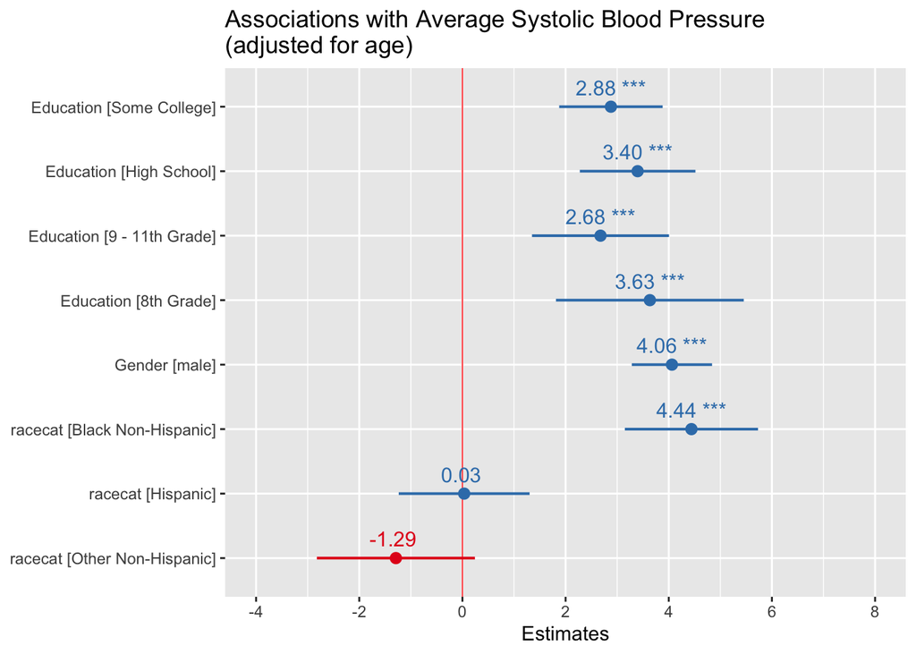

```r
# Plotting models ---------------------------------------------------------


# We can also add value labels and a title
plot_model(lm_model3,
           show.values=TRUE, value.offset=0.3,
           title="Associations with Average Systolic Blood Pressure (adjusted for age)",
           vline.color="red",
           terms = c("factor(Education)Some College",
                     "factor(Education)High School",
                     "factor(Education)9 - 11th Grade",
                     "factor(Education)8th Grade",
                     "Gendermale",
                     "factor(racecat)Black Non-Hispanic",
                     "factor(racecat)Hispanic",
                     "factor(racecat)Other Non-Hispanic"))
```

# Example using `broom::tidy` and `ggplot`

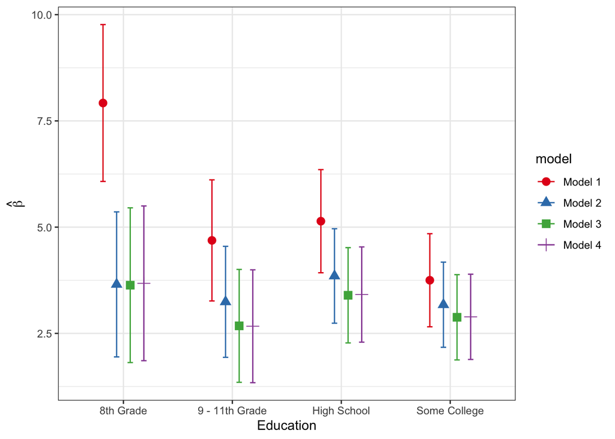

```r
# Comparing models visually -----------------------------------------------

# We want to compare estimates of the education effect in the crude and adjusted models
# Here, I show an example of using broom::tidy to extract the model estimates,
# stacking them together in a tibble,
# filtering out just the education terms,
# and piping the tibble into ggplot in order to plot the estimates.

# Extract the education effects from each model and combine in a tibble
lm_education_estimates <- bind_rows(broom::tidy(lm_model1, conf.int=TRUE) %>%
                                      mutate(model = "Model 1"),
                                    broom::tidy(lm_model2, conf.int=TRUE) %>%
                                      mutate(model = "Model 2"),
                                    broom::tidy(lm_model3, conf.int=TRUE) %>%
                                      mutate(model = "Model 3"),
                                    broom::tidy(lm_model4, conf.int=TRUE) %>%
                                      mutate(model = "Model 4")) %>%
  # here, we use stringr::str_detect to detect the entries
  # where term includes the string 'Education'
  filter(stringr::str_detect(term, "Education")) %>%
  # here, we use the separate() function to pull out the category labels
  # from term so that we can have nice labeling in the plot
  separate(col=term, sep=17, into=c("term", "category"), convert=TRUE)


# Use ggplot to plot the point estimates and 95% CIs
# Note that we are differentiating the models by color AND by the shape of the plotting symbol
ggplot(lm_education_estimates, aes(x=category, y=estimate, color=model, shape=model)) +
  # position=position_dodge() is specified so that the estimates are side by side rather than
  # plotted on top of one another
    geom_point(position=position_dodge(0.5), size=3) +
  # geom_errorbar allows us to plot the 95% confidence limits
    geom_errorbar(aes(ymin=conf.low, ymax=conf.high), position=position_dodge(0.5), width=0.2) +
  # scale_color_brewer allows me to control the colors for plotting the different models
    scale_color_brewer(palette="Set1") +
    labs(x="Education", y=expression(hat(beta))) +
    theme_bw()
```

# Plotting using `ggstatsplot`

We can use the `ggcoefstats()` function from the `ggstatsplot` package as well.

A few things to note here:

- `sort='none'` specifies no sorting of the effects so they appear in the order that they are specified in the `lm()` model call. But note that they are being plotted from the bottom of the plot going up (rather than from the top going down as in `sjPlot::plot_model`)
- To make this figure readable, we adjusted the `fig.width` and `fig.height` chunk options (see Rmd), otherwise everything was too squished.
- `stats.labels` gives us these helpful labels with the actual $\hat{\beta}$ estimates. `ggcoefstats` is using the `ggrepel` package so that these labels repel away from each other and from the data points. Additional arguments can be passed to `ggrepel::geom_label_repel()` via the `stats.label.args` argument.

```r
ggcoefstats(lm_model3,
            exclude.intercept = TRUE,
            stats.labels = TRUE,
            xlab = "Estimate",
            ylab = "Effect",
            title = "Model 3: Associations with average systolic blood pressure",
            sort = "none")
```

```
## Number of labels is greater than default palette color count.
## • Select another color `palette` (and/or `package`).
```

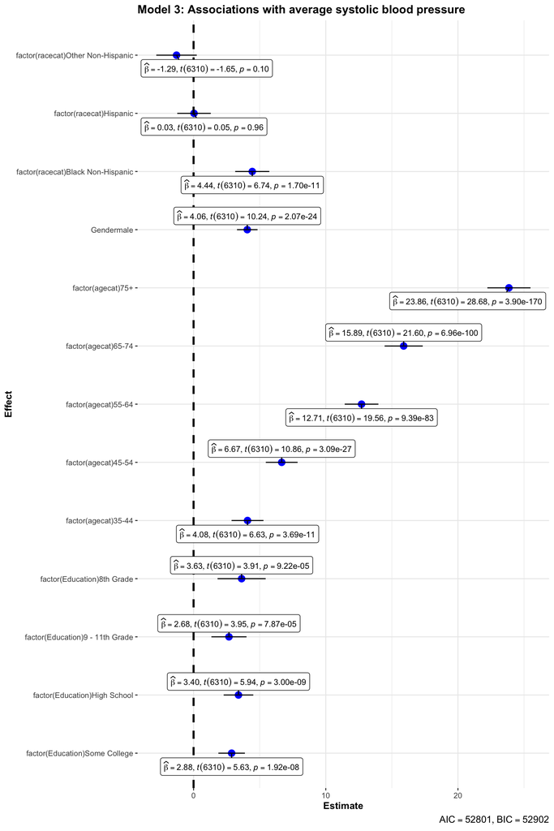